# 9 Nearest Resource Analysis

## 9.1 Overview

Spatial access to specific resources is often considered a multidimensional concept, though geographic distance is central to many measures of access. **Distance to the nearest resource** is a common metric used to characterize geographic access.

In this tutorial, we demonstrate how to calculate the minimum straight-line distance from each Chicago ZIP Code area centroid to the nearest methadone clinic in our dataset. Each area will be assigned a minimum distance metric representing proximity from its centroid to the nearest clinic.

Our objectives are thus to:

- Generate centroids from areal data
- Calculate the minimum distance from each area centroid to the nearest resource
- Map the minimum distance metric and overlay resource locations

## 9.2 Environment Setup

To replicate the code and functions illustrated in this tutorial, you’ll need to have R and RStudio downloaded and installed on your system. This tutorial assumes some familiarity with the R programming language.

### 9.2.1 Input/Output

Our inputs will be the clinic points generated in previous tutorials and the Chicago ZIP Code area boundaries.

- Chicago Methadone Clinics: `methadone_clinics.shp`
- Chicago ZIP Code Areas: `chicago_zips.shp`

We will calculate the minimum straight-line distance from each area centroid to the nearest methadone clinic, then save the results as a shapefile and a CSV file. Both outputs will include the minimum distance value for each area, and the shapefile will also retain the area boundaries for mapping.

If you don’t have a shapefile of your resource locations but already have longitude and latitude coordinates as two columns in a CSV file, you can still use this tutorial. For a reminder of how to convert these coordinates into an `sf` object in R, see [here](https://healthyregions.github.io/opioid-environment-toolkit/geocoding.html).

### 9.2.2 Load Libraries

We will use the following packages in this tutorial:

- `sf`: to manipulate spatial data
- `tmap`: to visualize and create maps
- `units`: to convert distance units

First, load the required libraries.

```r
library(sf)
library(tmap)
library(units)
```

## 9.3 Load Data

First, load the methadone clinic locations generated in the previous tutorials.

```r
methadoneSf <- st_read("data/methadone_clinics.shp")
```

Let’s take a look at the first few rows of the dataset.

```r
head(methadoneSf)
```

```
Simple feature collection with 6 features and 8 fields
Geometry type: POINT
Dimension:     XY
Bounding box:  xmin: -87.67818 ymin: 41.89268 xmax: -87.63409 ymax: 41.96475
Geodetic CRS:  WGS 84
  X                                                         Name
1 1                Chicago Treatment and Counseling Center, Inc.
2 2                      Sundace Methadone Treatment Center, LLC
3 3 Soft Landing Interventions/DBA Symetria Recovery of Lakeview
4 4                                        PDSSC - Chicago, Inc.
5 5                          Center for Addictive Problems, Inc.
6 6                                Family Guidance Centers, Inc.
                  Address    City State   Zip
1 4453 North Broadway st. Chicago    IL 60640
2 4545 North Broadway St. Chicago    IL 60640
```

[output cut: 18 more lines]

Next, load the Chicago ZIP Code area boundaries.

```r
chicagoZips <- read_sf("data/chicago_zips.shp")
```

We can quickly plot both datasets on an interactive map to check that the clinic locations and area boundaries appear in the expected locations.

```r
tmap_mode("view")

tm_shape(chicagoZips) +
  tm_borders() +
  tm_shape(methadoneSf) +
  tm_dots(col = "blue", size = 0.2)
```

[interactive chart not shown]

## 9.4 Calculate Centroids

Now, we will calculate the centroids of the ZIP Code areas. A centroid represents the geometric center of an area. We will first transform our data from geographic coordinates (longitude and latitude) to a projected coordinate reference system suitable for the Chicago area. This allows us to calculate centroids and straight-line distances using planar coordinates.

We’ll use NAD83 / Illinois East (ftUS), with an EPSG code of 3435. This coordinate reference system uses US survey feet.

**Note**: When choosing a projection for your own data, check its geographic coverage and units. States may have multiple State Plane zones, so choose one appropriate for your study area. You can review the [EPSG:3435 reference page](https://epsg.io/3435) for the projection used here.

Use the `st_transform()` function to change the projection of the data. Notice that the geometry coordinates are now expressed in US survey feet rather than degrees.

```r
chicagoZips <- st_transform(chicagoZips, 3435)

chicagoZips
```

```
Simple feature collection with 61 features and 4 fields
Geometry type: MULTIPOLYGON
Dimension:     XY
Bounding box:  xmin: 1091131 ymin: 1813892 xmax: 1205199 ymax: 1951669
Projected CRS: NAD83 / Illinois East (ftUS)
# A tibble: 61 × 5
   objectid shape_area shape_len zip                                    geometry
 *    <dbl>      <dbl>     <dbl> <chr>           <MULTIPOLYGON [US_survey_foot]>
 1       33 106052287.    42720. 60647 (((1162711 1913303, 1162716 1913153, 116…
 2       34 127476051.    48104. 60639 (((1149304 1914986, 1149278 1914985, 114…
 3       35  45069038.    27289. 60707 (((1133505 1909960, 1133422 1909959, 113…
 4       36  70853834.    42528. 60622 (((1165664 1902792, 1165664 1902792, 116…
 5       37  99039621.    47970. 60651 (((1154895 1905153, 1154850 1905152, 115…
 6       38  23506056.    34689. 60611 (((1180097 1904617, 1180187 1904468, 118…
 7       39 166166339.    67711. 60638 (((1145038 1877098, 1145039 1877014, 114…
 8       40 128309832.    48188. 60652 (((1161676 1854861, 1161677 1854816, 116…
 9        1  49170579.    33984. 60626 (((1166067 1951049, 1166073 1951045, 116…
10        8  66565455.    38321. 60615 (((1189361 1872143, 1189399 1872137, 118…
# ℹ 51 more rows
```

Then, calculate the centroids using `st_centroid()`.

```r
chicagoCentroids <- st_centroid(chicagoZips)

chicagoCentroids
```

```
Simple feature collection with 61 features and 4 fields
Geometry type: POINT
Dimension:     XY
Bounding box:  xmin: 1099728 ymin: 1816631 xmax: 1196586 ymax: 1946581
Projected CRS: NAD83 / Illinois East (ftUS)
# A tibble: 61 × 5
   objectid shape_area shape_len zip                   geometry
 *    <dbl>      <dbl>     <dbl> <chr> <POINT [US_survey_foot]>
 1       33 106052287.    42720. 60647        (1155996 1914470)
 2       34 127476051.    48104. 60639        (1141373 1914133)
 3       35  45069038.    27289. 60707        (1130559 1913877)
 4       36  70853834.    42528. 60622        (1160957 1907958)
 5       37  99039621.    47970. 60651        (1145478 1907585)
 6       38  23506056.    34689. 60611        (1178933 1904906)
 7       39 166166339.    67711. 60638        (1138048 1866268)
 8       40 128309832.    48188. 60652        (1153783 1850666)
 9        1  49170579.    33984. 60626        (1164639 1946581)
10        8  66565455.    38321. 60615        (1183244 1871247)
# ℹ 51 more rows
```

This creates one point for each ZIP Code area while retaining the original attributes. If you run this code directly in R, you may see a warning that `st_centroid()` assumes attributes are constant over each geometry. The attributes are carried over from the original areas; they are not recalculated for the centroid locations.

These centroids represent geometric centers rather than population centers. For irregularly shaped areas, a centroid may fall outside the area boundary.

We can plot the boundaries and centroids to check their locations. The `st_geometry()` function extracts the geometry from each spatial object so that we can plot it without the attribute data.

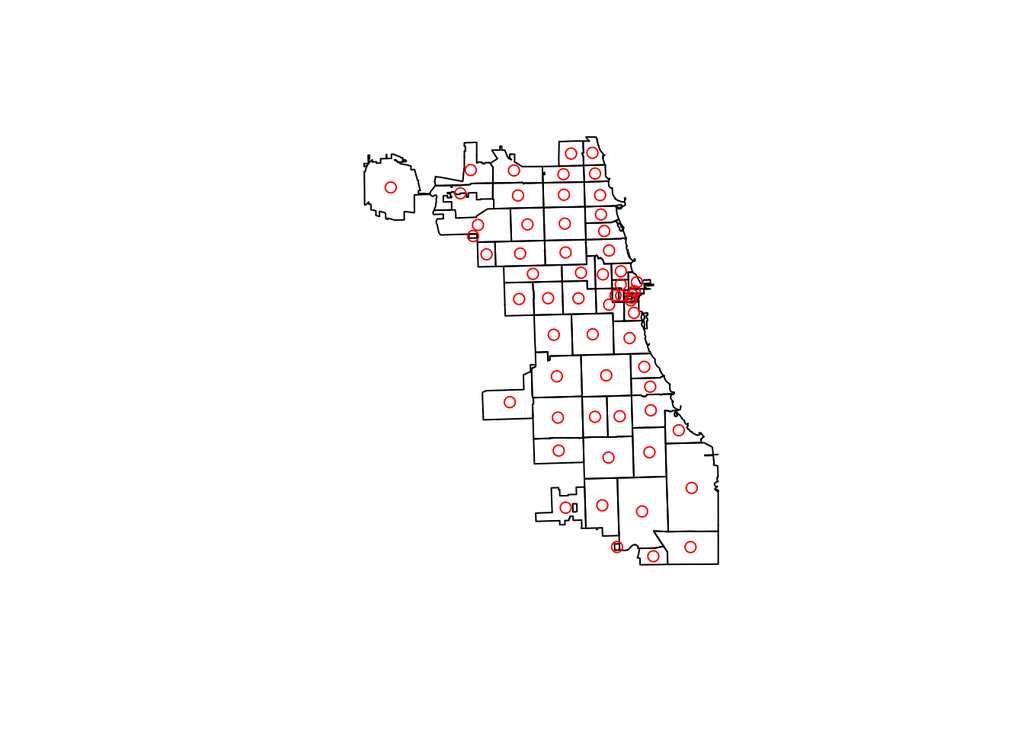

```r
plot(st_geometry(chicagoZips))
plot(st_geometry(chicagoCentroids), add = TRUE, col = "red")
```

### 9.4.1 Visualize & Confirm

Once again, we can create an interactive map to explore the area boundaries and centroid locations.

```r
tmap_mode("view")

tm_shape(chicagoZips) +
  tm_borders() +
  tm_shape(chicagoCentroids) +
  tm_dots()
```

[interactive chart not shown]

## 9.5 Standardize CRS

Before calculating distances between the area centroids and the resource locations, we need to make sure that both datasets use the same coordinate reference system (CRS). In the previous section, we projected the ZIP Code areas before calculating their centroids, but the clinic locations still use their original CRS. Attempting to calculate distances with `st_distance()` while these coordinate reference systems differ will produce an error.

First, use `st_crs()` to inspect the coordinate reference system of each dataset.

```r
st_crs(chicagoCentroids)
```

```
Coordinate Reference System:
  User input: EPSG:3435
  wkt:
PROJCRS["NAD83 / Illinois East (ftUS)",
    BASEGEOGCRS["NAD83",
        DATUM["North American Datum 1983",
            ELLIPSOID["GRS 1980",6378137,298.257222101,
                LENGTHUNIT["metre",1]]],
        PRIMEM["Greenwich",0,
            ANGLEUNIT["degree",0.0174532925199433]],
        ID["EPSG",4269]],
    CONVERSION["SPCS83 Illinois East zone (US survey foot)",
        METHOD["Transverse Mercator",
            ID["EPSG",9807]],
        PARAMETER["Latitude of natural origin",36.6666666666667,
            ANGLEUNIT["degree",0.0174532925199433],
            ID["EPSG",8801]],
        PARAMETER["Longitude of natural origin",-88.3333333333333,
            ANGLEUNIT["degree",0.0174532925199433],
            ID["EPSG",8802]],
        PARAMETER["Scale factor at natural origin",0.999975,
            SCALEUNIT["unity",1],
            ID["EPSG",8805]],
        PARAMETER["False easting",984250,
            LENGTHUNIT["US survey foot",0.304800609601219],
            ID["EPSG",8806]],
        PARAMETER["False northing",0,
            LENGTHUNIT["US survey foot",0.304800609601219],
            ID["EPSG",8807]]],
    CS[Cartesian,2],
        AXIS["easting (X)",east,
            ORDER[1],
            LENGTHUNIT["US survey foot",0.304800609601219]],
        AXIS["northing (Y)",north,
            ORDER[2],
            LENGTHUNIT["US survey foot",0.304800609601219]],
    USAGE[
        SCOPE["Engineering survey, topographic mapping."],
        AREA["United States (USA) - Illinois - counties of Boone; Champaign; Clark; Clay; Coles; Cook; Crawford; Cumberland; De Kalb; De Witt; Douglas; Du Page; Edgar; Edwards; Effingham; Fayette; Ford; Franklin; Gallatin; Grundy; Hamilton; Hardin; Iroquois; Jasper; Jefferson; Johnson; Kane; Kankake…
        BBOX[37.06,-89.27,42.5,-87.02]],
    ID["EPSG",3435]]
```

```r
st_crs(methadoneSf)
```

```
Coordinate Reference System:
  User input: WGS 84
  wkt:
GEOGCRS["WGS 84",
    DATUM["World Geodetic System 1984",
        ELLIPSOID["WGS 84",6378137,298.257223563,
            LENGTHUNIT["metre",1]]],
    PRIMEM["Greenwich",0,
        ANGLEUNIT["degree",0.0174532925199433]],
    CS[ellipsoidal,2],
        AXIS["latitude",north,
            ORDER[1],
            ANGLEUNIT["degree",0.0174532925199433]],
        AXIS["longitude",east,
            ORDER[2],
            ANGLEUNIT["degree",0.0174532925199433]],
    ID["EPSG",4326]]
```

The centroids use NAD83 / Illinois East (ftUS), while the clinic locations use WGS 84. We’ll take the CRS from the centroid data and use it as the target CRS when transforming the clinic locations with `st_transform()`.

```r
newCRS <- st_crs(chicagoCentroids)

methadoneSf <- st_transform(methadoneSf, newCRS)
```

We can now check that the coordinate reference systems match.

```r
st_crs(chicagoCentroids) == st_crs(methadoneSf)
```

```
[1] TRUE
```

The result should be `TRUE`, indicating that both datasets use the same CRS. Mismatched coordinate reference systems are a common issue in geospatial data processing, so it is helpful to check them before conducting spatial analysis.

Now we can plot the ZIP Code area boundaries, their centroids, and the clinic locations together. Centroids are shown in red and clinics in blue.

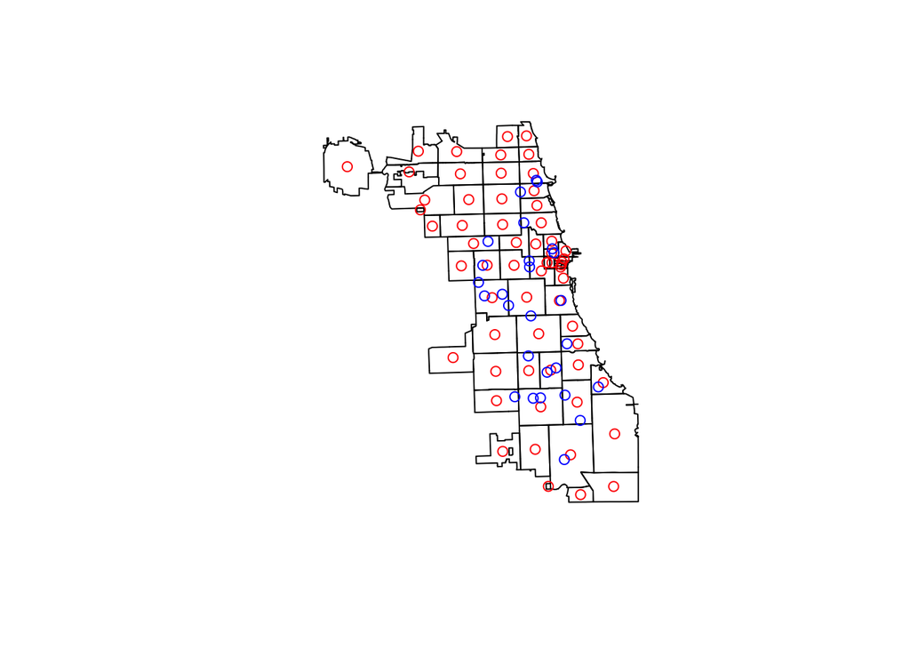

```r
plot(st_geometry(chicagoZips))
plot(st_geometry(chicagoCentroids), col = "red", add = TRUE)
plot(st_geometry(methadoneSf), col = "blue", add = TRUE)
```

Next, we will calculate the distance from each area centroid to its nearest resource.

## 9.6 Calculate Distance

First, we’ll identify the clinic closest to each ZIP Code area centroid using `st_nearest_feature()`. This function returns the row index of the nearest clinic in `methadoneSf`. We can use these indices to select the corresponding clinic for each centroid.

```r
nearestClinic_indexes <- st_nearest_feature(chicagoCentroids, methadoneSf)

nearestClinic <- methadoneSf[nearestClinic_indexes, ]

head(nearestClinic)
```

```
Simple feature collection with 6 features and 8 fields
Geometry type: POINT
Dimension:     XY
Bounding box:  xmin: 1150707 ymin: 1904257 xmax: 1174632 ymax: 1915110
Projected CRS: NAD83 / Illinois East (ftUS)
    X                                Name             Address    City State
4   4               PDSSC - Chicago, Inc. 2260 N. Elston Ave. Chicago    IL
7   7            A Rincon Family Services  3809 W. Grand Ave. Chicago    IL
7.1 7            A Rincon Family Services  3809 W. Grand Ave. Chicago    IL
4.1 4               PDSSC - Chicago, Inc. 2260 N. Elston Ave. Chicago    IL
7.2 7            A Rincon Family Services  3809 W. Grand Ave. Chicago    IL
5   5 Center for Addictive Problems, Inc.    609 N. Wells St. Chicago    IL
      Zip                              fullAdd geo_method
4   60614 2260 N. Elston Ave. Chicago IL 60614     census
7   60651  3809 W. Grand Ave. Chicago IL 60651     census
7.1 60651  3809 W. Grand Ave. Chicago IL 60651     census
4.1 60614 2260 N. Elston Ave. Chicago IL 60614     census
7.2 60651  3809 W. Grand Ave. Chicago IL 60651     census
5   60654    609 N. Wells St. Chicago IL 60654     census
                   geometry
4   POINT (1163663 1915110)
7   POINT (1150707 1908328)
7.1 POINT (1150707 1908328)
4.1 POINT (1163663 1915110)
7.2 POINT (1150707 1908328)
5   POINT (1174632 1904257)
```

The resulting dataset has one row for each centroid, in the same order as `chicagoCentroids`. A clinic may appear more than once if it is the nearest resource for multiple areas.

Next, calculate the straight-line distance between each centroid and its nearest clinic using `st_distance()`. Both datasets now use the same projected CRS.

Setting `by_element = TRUE` calculates the distance between corresponding rows: the first centroid and its matched clinic, the second centroid and its matched clinic, and so on.

```r
minDist <- st_distance(chicagoCentroids, nearestClinic, by_element = TRUE)

head(minDist)
```

```
Units: [US_survey_foot]
[1]  7693.750 10991.183 20898.175  7646.830  5281.355  4350.383
```

The distances are expressed in US survey feet, the units of our projected CRS. To convert them to miles, use `set_units()`.

```r
minDist_mi <- set_units(minDist, "mi")

head(minDist_mi)
```

```
Units: [mi]
[1] 1.4571526 2.0816677 3.9579957 1.4482662 1.0002587 0.8239379
```

### 9.6.1 Merge Data

We can now add the minimum distances to the original ZIP Code area data. Because the centroids were created from `chicagoZips` and their row order has not changed, each distance corresponds to the same row in the original dataset.

We will store the distances as numeric values for mapping and export. The field name `minDist_mi` indicates that the values are in miles.

```r
minDistSf <- chicagoZips
minDistSf$minDist_mi <- as.numeric(minDist_mi)

head(minDistSf)
```

```
Simple feature collection with 6 features and 5 fields
Geometry type: MULTIPOLYGON
Dimension:     XY
Bounding box:  xmin: 1127607 ymin: 1902374 xmax: 1184320 ymax: 1918596
Projected CRS: NAD83 / Illinois East (ftUS)
# A tibble: 6 × 6
  objectid shape_area shape_len zip                          geometry minDist_mi
     <dbl>      <dbl>     <dbl> <chr> <MULTIPOLYGON [US_survey_foot]>      <dbl>
1       33 106052287.    42720. 60647 (((1162711 1913303, 1162716 19…      1.46
2       34 127476051.    48104. 60639 (((1149304 1914986, 1149278 19…      2.08
3       35  45069038.    27289. 60707 (((1133505 1909960, 1133422 19…      3.96
4       36  70853834.    42528. 60622 (((1165664 1902792, 1165664 19…      1.45
5       37  99039621.    47970. 60651 (((1154895 1905153, 1154850 19…      1.00
6       38  23506056.    34689. 60611 (((1180097 1904617, 1180187 19…      0.824
```

### 9.6.2 Visualize & Confirm

We can now visualize the minimum distance to methadone clinics using the `tmap` package. We’ll use five quantile classes, which group areas into approximately equal-sized groups based on their distance values.

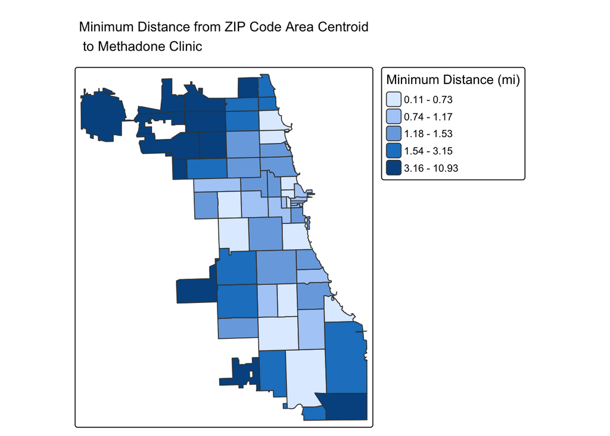

```r
tmap_mode("plot")

tm_shape(minDistSf) +
  tm_polygons(
    fill = "minDist_mi",
    fill.scale = tm_scale_intervals(style = "quantile", n = 5),
    fill.legend = tm_legend(title = "Minimum Distance (mi)")
  ) +
  tm_title(
    "Minimum Distance from ZIP Code Area Centroid\n to Methadone Clinic",
    position = tm_pos_out("center", "top"),
    size = 1
  )
```

We can also overlay the clinic locations to help interpret the distance patterns.

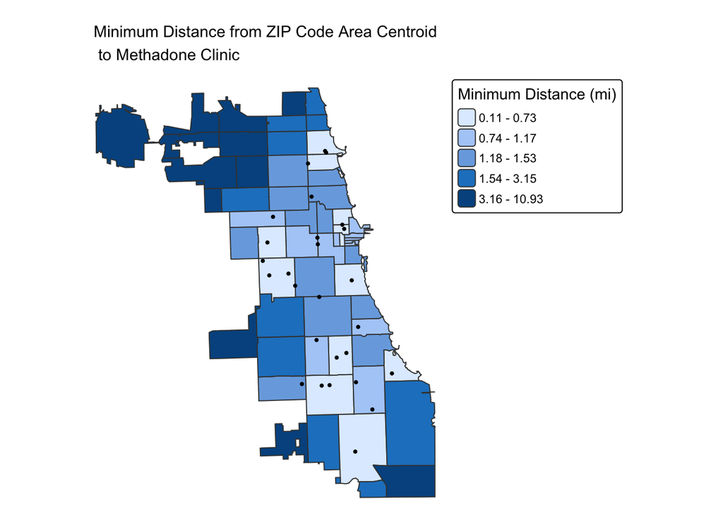

```r
tm_shape(minDistSf) +
  tm_polygons(
    fill = "minDist_mi",
    fill.scale = tm_scale_intervals(style = "quantile", n = 5),
    fill.legend = tm_legend(title = "Minimum Distance (mi)")
  ) +
  tm_shape(methadoneSf) +
  tm_dots(size = 0.2) +
  tm_title(
    "Minimum Distance from ZIP Code Area Centroid\n to Methadone Clinic",
    position = tm_pos_out("center", "top"),
    size = 1
  ) +
  tm_layout(frame = FALSE)
```

### 9.6.3 Interpret Distance Measures

Smaller values indicate that an area’s centroid is closer to a clinic in our dataset. These values describe proximity from the centroid rather than from every resident’s location.

When interpreting the results, it helps to distinguish three measures:

- **Straight-line distance** measures the direct distance between two locations. This is the measure calculated in this chapter.
- **Network distance** measures the length of a route along a transportation network, such as roads or walking paths. Rivers, limited crossings, and road layouts can make this route longer than the straight-line distance.
- **Travel time** measures how long a journey takes. It depends on the route, mode of transportation, and travel conditions.

The nearest clinic by straight-line distance may therefore differ from the nearest clinic by road distance or travel time. For example, a clinic across a river may appear close on the map but require a longer journey to reach a bridge.

Calculating network distance or travel time requires additional routing data or a routing service; converting the straight-line distances from feet to miles does not change the type of distance measured.

Like the buffer-based measures in the previous chapter, nearest distance describes proximity without directly incorporating population demand or treatment capacity. In the Advanced Access Metrics chapter, we will use prepared travel-time data alongside resource supply and population-based demand to explore these additional aspects of access.

## 9.7 Save Data

We can save the area attributes and minimum distance values as a CSV file. Use `st_drop_geometry()` to remove the spatial geometry and `row.names = FALSE` to avoid adding an extra row-number column.

```r
write.csv(
  st_drop_geometry(minDistSf),
  "data/chizips_Access.csv",
  row.names = FALSE
)
```

We can also save the results as a shapefile, retaining the area boundaries for future mapping and spatial analysis.

```r
write_sf(minDistSf, "data/chizips_Access.shp")
```

The `minDist_mi` field in both outputs contains the minimum straight-line distance to the nearest clinic in miles.